# Pharmacokinetics (PK) Study Notes (with Plots & Derivations)

### **1. Introduction to Pharmacokinetics (PK)**

Pharmacokinetics is the study of *what the body does to a drug*. It is often summarized by the acronym **ADME**:

- **Absorption:** How the drug gets into the bloodstream.
- **Distribution:** Where the drug goes in the body.
- **Metabolism:** How the body breaks down the drug.
- **Excretion:** How the body removes the drug.

### **2. Key PK Parameters**

- **Volume of Distribution ($V_d$):** An *apparent* volume that describes how widely a drug distributes throughout the body.
- **Clearance ($CL$):** The volume of blood cleared of a drug per unit of time. It represents the body’s efficiency at eliminating the drug.

### **3. Area Under the Curve (AUC)**

AUC represents the **total exposure** of the body to a drug after a dose.

#### **Example Plot: Visualizing AUC**

This plot shows the concentration of a drug in the blood over time after an IV bolus dose. The shaded region represents the total drug exposure, or AUC.

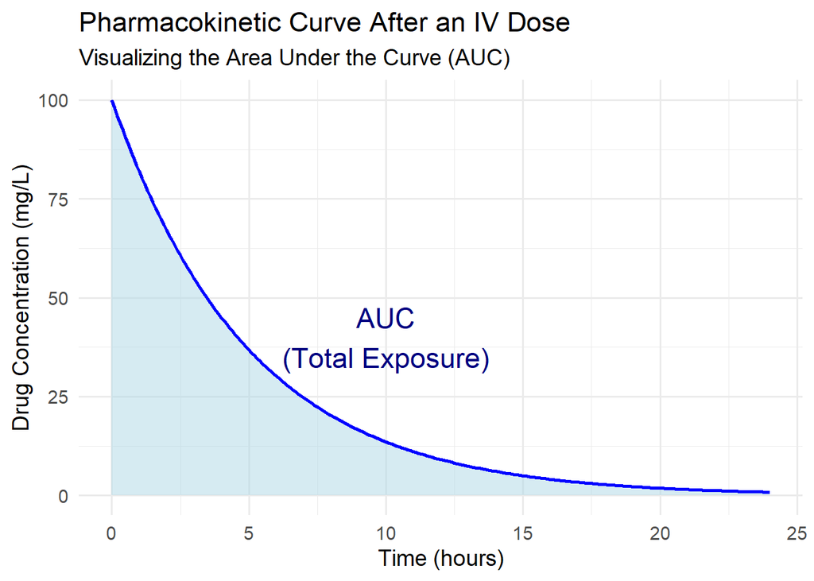

### **4. Pharmacokinetic Models**

#### **Example Plot: One- vs. Two-Compartment Models**

This plot shows the concentration decline over time on a log-scale. The one-compartment model shows a simple, mono-exponential decay. The two-compartment model shows a “biexponential” decay, with a fast initial drop (distribution phase) followed by a slower decline (elimination phase).

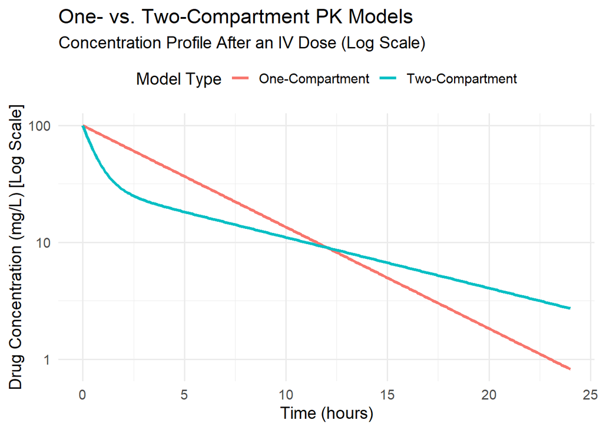

### **5. Oral Dosing**

When a drug is taken orally, it must be absorbed first. This leads to new parameters:

- **$C_{max}$**: The **maximum concentration** the drug reaches.
- **$T_{max}$**: The **time** at which $C_{max}$ occurs.

#### **Example Plot: Oral Dosing Curve**

This plot shows the characteristic rise-and-fall of drug concentration after a pill is taken.

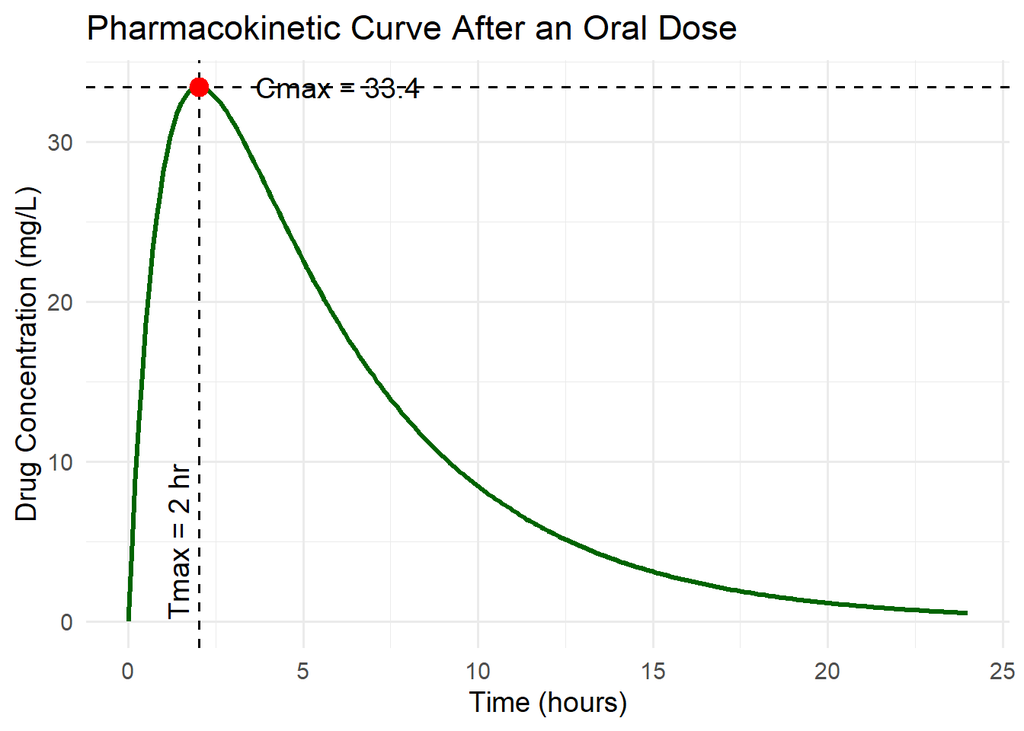

### **6. Bioavailability (F) & Bioequivalence**

- **Bioavailability (F):** The fraction (%) of an oral dose that successfully reaches the bloodstream.
- **Bioequivalence:** The standard used to ensure a generic drug performs the same as a brand-name drug.

### **7. Mathematical Derivations & Relationships**

#### **Derivation of $AUC = \frac{Dose}{CL}$**

1. **Start with the definition of AUC:** The integral of the concentration function $C(t)$ from time 0 to infinity.
   $$AUC =
   \int_0^\infty C(t) \,dt$$
2. **Substitute the concentration equation** for a one-compartment model: $C(t) = C_0 \cdot e^{-k_e \cdot t}$
   $$AUC =
   \int_0^\infty (C_0 \cdot e^{-k_e \cdot t}) \,dt = C_0 \int_0^\infty
   e^{-k_e \cdot t} \,dt$$
3. **Solve the integral:**
   $$AUC = C_0 \left[ -\frac{1}{k_e}e^{-k_e \cdot t}
   \right]_0^\infty = C_0 \left( 0 - (-\frac{1}{k_e}) \right) =
   \frac{C_0}{k_e}$$
4. **Substitute known parameter relationships:** We know that $C_0 = \frac{Dose}{V_d}$ and $CL = V_d \cdot k_e$.
   $$AUC = \frac{(Dose / V_d)}{k_e} = \frac{Dose}{V_d
   \cdot k_e}$$
5. **Final Result:**
   $$AUC =
   \frac{Dose}{CL}$$

#### **Core Parameter Relationships**

- **Why is $C_0 = \frac{Dose}{V_d}$?**
  - This comes from the fundamental definition of concentration: $Concentration = \frac{Amount}{Volume}$. In PK at time zero, the Amount is the `Dose`, the Volume is the apparent `Volume of Distribution`, and the Concentration is `$C_0$`.
- **Why is $CL = V_d \cdot k_e$?**
  - The elimination rate constant ($k_e$) is the *fraction* of drug eliminated per unit time.
  - Therefore, the `Rate of Elimination` = $k_e \times (\text{Amount of drug in body})$.
  - Since `Amount` = `Concentration` $\times$ `Volume`, we can write: `Rate of Elimination` = $k_e \times C(t) \times V_d$.
  - Clearance is also defined as the rate of elimination normalized by the concentration: $CL = \frac{\text{Rate of Elimination}}{C(t)}$.
  - Substituting gives: $CL = \frac{k_e \cdot C(t) \cdot V_d}{C(t)}$. The concentration terms $C(t)$ cancel out, leaving $CL = V_d \cdot k_e$.